# Quarto Introduction – BIOS 6312 - Spring 2026

## Learning Objectives

1. Open the quarto introduction file in your Rstudio and render to create an html output file
2. Learn some basic markdown syntax to include text and run code
3. Alter the YAML to include your name and output to a different file format (e.g. docx)

## R packages used

For this introduction, I used three R packages. If you have never used these before, they will need to be installed once, e.g.

```r
install.packages("ggplot2")
install.packages("rms")
install.packages("Hmisc")
```

If they have already been installed, you can load these packages.

```r
library(ggplot2)
library(rms)
library(Hmisc)
```

Quarto includes many more features than I will cover in this course. It is *not* a learning objective of this course that you learn all of the features included in Quarto. Instead, I want to cover a few of the most useful things and provide a starting point for those interested in learning more.

[output not shown]

### Plots

You can include plots

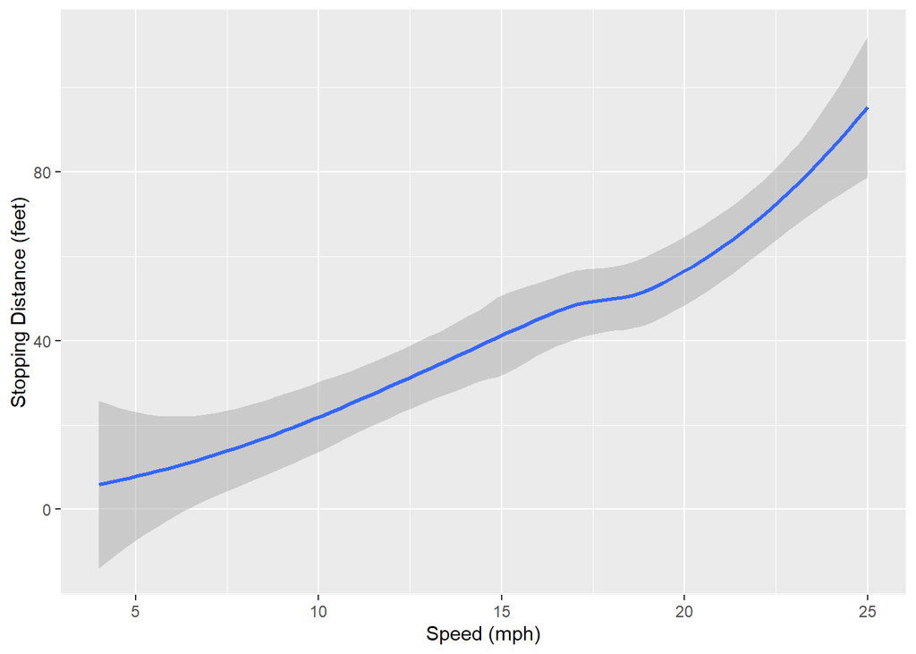

Date recorded in the 1920s

```r
ggplot(cars, aes(x=speed, y=dist)) +
  geom_smooth() +
  xlab("Speed (mph)") +
  ylab("Stopping Distance (feet)")
```

Speed and stopping distance of cars

### Tables

And tables that are simple text

```r
# Create some data
set.seed(12345) # Fpr reproducibility
exampledata <- data.frame(age=rnorm(500,50,5),
                          sbp=rnorm(500,120,12),
                          trt=factor(sample(c("Drug","Placebo"), 500, replace=TRUE))
)
f <- summaryM(age + sbp ~ trt, data=exampledata, test=TRUE)
print(f, digits=2)
```

```
Descriptive Statistics  (N=500)

+---+------------------+------------------+------------------------+
|   |Drug              |Placebo           |  Test                  |
|   |(N=260)           |(N=240)           |Statistic               |
+---+------------------+------------------+------------------------+
|age|        47/50/53  |        47/51/54  | F=0.5 d.f.=1,498 P=0.48|
+---+------------------+------------------+------------------------+
|sbp|       113/120/129|       112/120/128|F=0.02 d.f.=1,498 P=0.89|
+---+------------------+------------------+------------------------+
```

Table can also be formatted to improve appearance. Here is an html version of the same table.

```r
html(f, digits=3)
```

| Descriptive Statistics *(N=500)*. | Descriptive Statistics *(N=500)*. Drug *N=260* | Descriptive Statistics *(N=500)*. Placebo *N=240* | Descriptive Statistics *(N=500)*. Test Statistic |
| --- | --- | --- | --- |
| age | 47.4 50.3 53.2 | 47.0 50.7 54.0 | *F*<sub>1 498</sub>=0.5, P=0.479 |
| sbp | 113 120 129 | 112 120 128 | *F*<sub>1 498</sub>=0.02, P=0.89 |

*a* *b* *c* represent the lower quartile *a*, the median *b*, and the upper quartile *c* for continuous variables. Test used: Wilcoxon test .

## Quarto YAML

The beginning of this document of the document contains metadata that controls the document appearance, output format, and many other options. The current lines were automatically generated when I create a new document (**File** > **New File** > **Quarto Document…**)

For longer documents, it can be useful to add a table of contents. A simple toc can added with the line.

```yaml
toc: true
```

Also, the default output type is an html document. This is a good choice, but if you prefer other options, you can alter the yaml to produce Word files, PDFs, or many other options. Tab-completion is supported to see the various options.

In order to create PDFs you will need to install a recent distribution of TeX. We recommend the use of TinyTeX (which is based on TexLive), which you can install with the following command:

```
quarto install tinytex
```

More details on [authoring Quarto documents in Rstudio](https://quarto.org/docs/get-started/authoring/rstudio.html) are available elsewhere.

## Thing to try

1. Alter the YAML to include your name
2. Alter the YAML to output to a different file format, e.g. docx
3. Add some text, code, or graphics and render the document